# Viewing Habits Analysis

## Introduction

This project explores how people watch TV shows and other video content based on a survey I designed and distributed. The survey includes questions about viewing frequency, daily watching hours, preferred devices, content types, and reasons for watching.

The goal of this analysis is to understand general viewing habits and identify patterns in how people consume shows, including differences across devices, content categories, and time of submission.

## Top Viewing Time Patterns

The top five entries show clear differences in viewing time, with one noticeably higher than the others. This suggests that while most Respondents watch a moderate number of hours per day; there are a few individuals with significantly higher viewing habits.

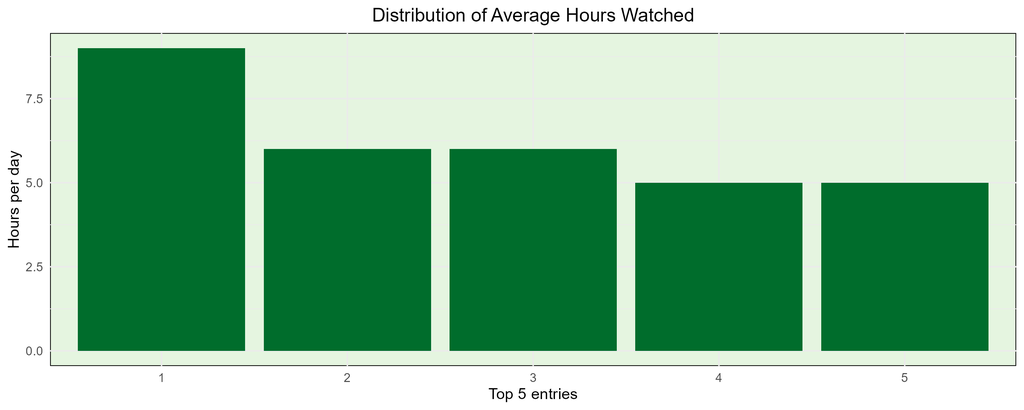

Bar chart showing the top five highest average hours watched per day.

## Viewing Behaviour by Device

Viewing time varies across devices, with iPad users showing a wider spread in viewing hours, while TV users tend to have lower and more consistent viewing times. This may indicate that portable devices are associated with more flexible or extended viewing habits.

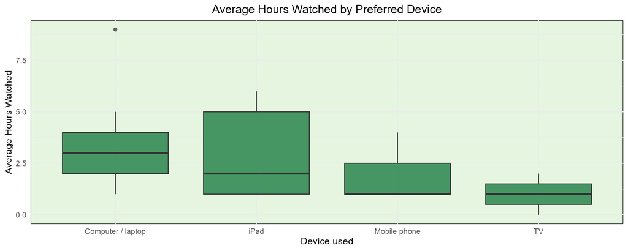

Boxplot comparing average hours watched across preferred devices including computer, iPad, mobile phone and TV.

## Content Type and Device Interaction

Series and movies generally have higher viewing times compared to other content types across most devices. This suggests that long-form entertainment content is more likely to be associated with longer viewing sessions, regardless of the device used.

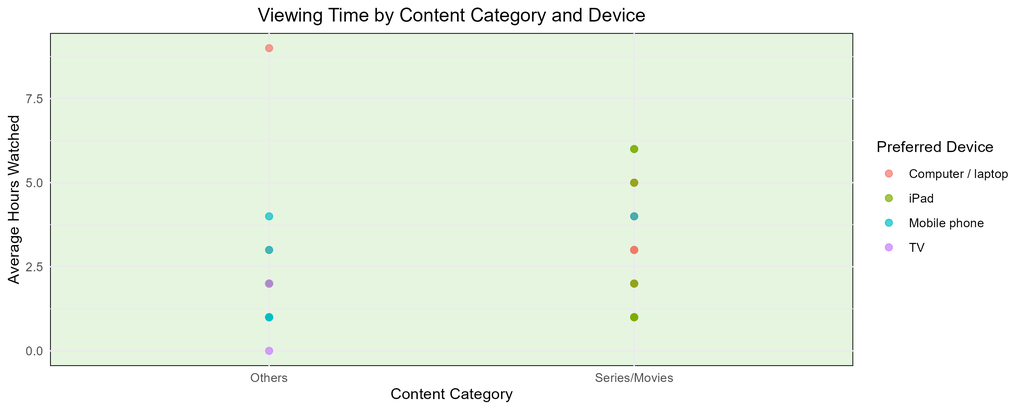

Point plot showing average hours watched by content category, with points coloured by preferred device.

## Survey Response Timing

Most survey responses were concentrated on a few specific dates. This suggests that the responses were collected in batches rather than continuously. It’s probably because my friends (just like me) tend to procrastinate a bit, so they only filled out the survey after I reminded them them near the deadline 😄

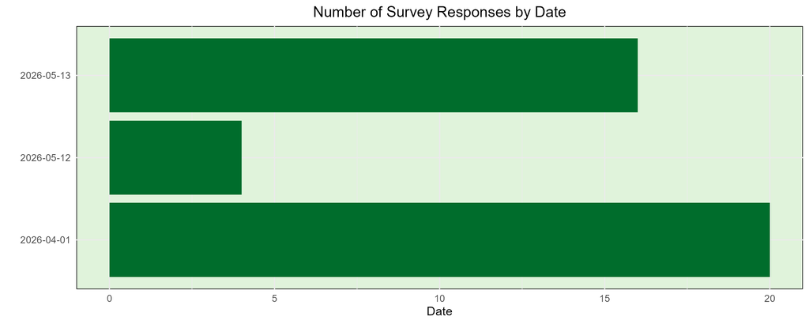

Bar chart showing the number of survey responses submitted on each date.

## Conclusion

Overall, the data show that viewing habits vary depending on both the device and the type of content being consumed. Long-form content such as series and movies tends to result in higher viewing times, while Device choice also plays a role in how consistently people watch shows.

These findings provide a simple but useful overview of viewing behaviour and demonstrate how survey data can be used to explore everyday media consumption patterns.